# The Power of Syntax

Comparing `polars`, `data.table`, and `dplyr`/`pandas`

Tyson S. Barrett, PhD

2025-02-02

## Sapir-Whorf Hypothesis

(“linguistic relativity”)

### Proposes that the language a person speaks influences how they think, perceive, and experience the world

- Color Perception
- Spatial Orientation
- Time and Grammatical Structures
- Gender and Cognition

# How does the language and syntax we code in affect our perceptions, plans, and thinking?

## Who am I?

[figure not shown]

[figure not shown]

[figure not shown]


## Brief History Lesson

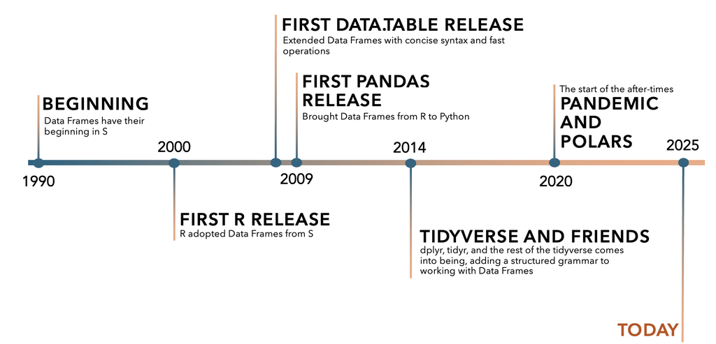

## The Packages

### `polars`

```python
# pip install polars
import polars as pl
```

### `data.table`

```r
# install.packages("data.table")
library(data.table)
```

### `dplyr` (`pandas`)

```r
# install.packages("dplyr")
library(dplyr)
```

## Not Just Speed

### https://duckdblabs.github.io/db-benchmark/

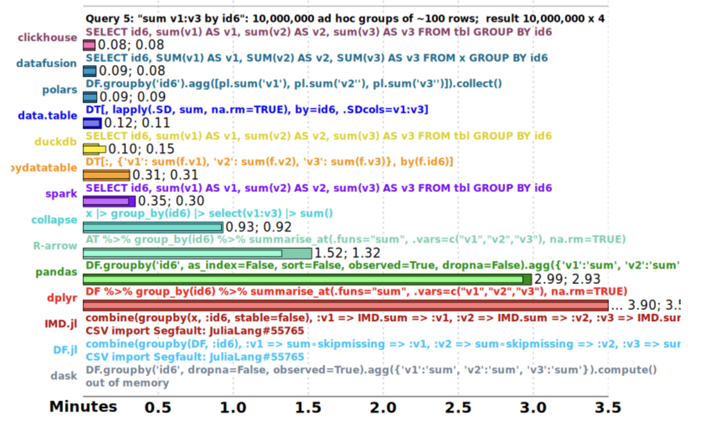

Note, fair benchmarking is [difficult](https://hannes.muehleisen.org/publications/DBTEST2018-performance-testing.pdf)

## Comparing Syntax

Comparing based on five related but distinct criteria:

- Verbosity and Readability
- Operation Chaining
- Column References
- Grouping Syntax
- Speed of Writing

## Verbosity and Readability

`dplyr` and `polars` built on some [shared verbs/synonyms](https://blog.tidy-intelligence.com/posts/dplyr-vs-polars/)

| Action | `polars` | `dplyr` |
| --- | --- | --- |
| Filter rows | `filter()` | `filter()` |
| Select columns | `select()` | `select()` |
| Manipulate columns | `with_columns()` | `mutate()` |
| Sort/arrange rows | `sort()` | `arrange()` |
| Rename columns | `rename()` | `rename()` |
| Summarize by groups | `group_by().agg()` | `group_by() %>% summarise()` |

## Verbosity and Readability

`data.table` in contrast has an implicit syntax

```
dt[i, j, by]
```

## Verbosity and Readability

`dt[i, j, by]`

Produces very concise syntax where position of syntax within `[]` and other symbols communicate intention

```r
dt[var == 1]             # filter
dt[, .(var, var2)]       # select
dt[, new := var + var2]  # mutate/with_columns
```

## Verbosity and Readability

How does this affect our use of the syntax?

- Data exploration
- Learning Curve
- Collaboration
- Production code

## Operation Chaining

All three packages offer operation chaining

- `polars`
- `data.table`
- `dplyr`

```python
pl3.select(pl.col("x", "y")).filter(pl.col("x") > 1)
```

```r
dt3[, .(x, y)][x > 1]
```

```r
df3 |>
  select(x, y) |>
  filter(x > 1)
```

## Operation Chaining

Unlike the others, `polars` can directly optimize your call behind the scenes (similar to other database engines)

```python
pl1 = pl.DataFrame({"foo": ["a", "b", "c"], "bar": [0, 1, 2]}).lazy()
pl2 = (
  pl1.with_columns(pl.col("foo").str.to_uppercase())
  .filter(pl.col("bar") > 0)
)
pl2.explain()
```

```
WITH_COLUMNS:
  [col("foo").str.uppercase()]
  DF ["foo", "bar"]; PROJECT */2 COLUMNS; SELECTION: [(col("bar")) > (0)]
```

## Operation Chaining

All three packages offer operation chaining

Unlike the others, `polars` can directly optimize your call behind the scenes (similar to other database engines)

```python
pl2.collect()
```

shape: (2, 2)

| foo str | bar i64 |
| --- | --- |
| "B" | 1 |
| "C" | 2 |

## Column References

- `polars`: Requires pl.col() for complex operations
- `data.table`: Direct column names within []
- `dplyr`: Direct column names

```python
import numpy as np
pl3 = pl.DataFrame({
    'x': range(1, 6),
    'y': ['a', 'a', 'a', 'b', 'b'],
    'z': np.random.rand(5)
})
```

[output not shown]

## Column References

- `polars`: Requires pl.col() for complex operations
- `data.table`: Direct column names within []
- `dplyr`: Direct column names

```python
import numpy as np
pl3 = pl.DataFrame({
    'x': range(1, 6),
    'y': ['a', 'a', 'a', 'b', 'b'],
    'z': np.random.rand(5)
})
```

- `polars`
- `data.table`
- `dplyr`

```python
pl3.select(pl.col("x", "y"))
```

shape: (5, 2)

| x i64 | y str |
| --- | --- |
| 1 | "a" |
| 2 | "a" |
| 3 | "a" |
| 4 | "b" |
| 5 | "b" |

```r
dt3[, .(x, y)]
```

```
       x      y
   <int> <char>
1:     1      a
2:     2      a
3:     3      a
4:     4      b
5:     5      b
```

```r
df3 %>% select(x, y)
```

```
# A tibble: 5 × 2
      x y
  <int> <chr>
1     1 a
2     2 a
3     3 a
4     4 b
5     5 b
```

## Grouping Syntax

Again, all three packages make this possible

- `polars`
- `data.table`
- `dplyr`

```python
pl3.group_by('y').agg(pl.sum('x'))
```

shape: (2, 2)

| y str | x i64 |
| --- | --- |
| "a" | 6 |
| "b" | 9 |

```r
dt3[, sum(x), by = y]
```

```
        y    V1
   <char> <int>
1:      a     6
2:      b     9
```

```r
df3 %>%
  group_by(y) %>%            # grouping
  summarise(sum_x = sum(x))
```

```
# A tibble: 2 × 2
  y     sum_x
  <chr> <int>
1 a         6
2 b         9
```

## Grouping Syntax

A few nuances:

- `summarise()` will message if multiple rows per group are found
- restrained in `polars` to use their functions whereas `data.table` and `dplyr` can use most functions in `R`

## Speed of Writing

- `polars` prioritizes “a well-structured, typed API that is both expressive and easy to use.”
- `dplyr` prioritizes code legibility using expressive verbs
- `data.table` prioritizes concise, symbol-based code

Of course, familiarity with the syntax is most important but assuming familiarity, `data.table` offers very high speed of writing while code snippets can be very useful for `polars` and `dplyr`

```python
import polars as pl
```

```r
library(data.table)
```

```r
library(dplyr)
```

## Closing Thoughts

- The way `polars` (and similar projects like `arrow` ) work are likely the future
  - `polars` is written in `Rust` making it transferable to other languages (e.g. `R` now has a `polars` package)
- `data.table` is highly used and will be for what looks like a long time
  - used in thousands of `R` packages and production code
- `dplyr` (and the `tidyverse`) helped structure the grammar
  - has amazing backends to make it possible for optimization and speed without developing a whole new framework